# Exploratory Analysis

LD

8/11/2020

```r
# My Black Counts Mini-Experiment
# Outreach Experiment in Alameda County and LA County
# Step 2: Exploratory analysis of the data.
options(scipen=999999)
library(car)
library(dplyr)
library(RPostgreSQL)
library(tidyr)
library(tidyverse)
library(ggplot2)
library(sf)
library(lme4)
library(here)

# Because this is in an R Project, the working directory paths are relative, not fixed

# loads the PostgreSQL driver
drv <- dbDriver("PostgreSQL")

# create connection to db
con <- dbConnect(drv, dbname = "census_2020",
                 host = "aws-postgres-db.c5udgz7ro8hq.us-west-2.rds.amazonaws.com", port = 5432,
                 user = "postgres", password = "password")

dat <- st_read(con, query = "SELECT * FROM mbc_experiment_zip_0720_0726")
```

## 1. Define Question

### Primary question:

- Did treatment zip codes have larger response rate gains than control zip codes?

### Secondary questions:

- Are there any variables correlated with higher response rate gains?
- Are there differences by county (Alameda vs. Los Angeles)?
- Are there additional contextual factors to consider?
  - E.g. phone banking outreach from MBC

## 2. Exploratory Analysis

### Explore experiment data

```r
## ----------------------
## Start with some simple summary stats -
## ----------------------


# breakdown of treatment v control in response rate increase quartiles
table(dat$exp_flag, dat$quart_resp_diff)
```

```
##
##              1  2  3  4
##   control    3  2 10  5
##   treatment  1  5  8  6
```

```r
# and by county
table(dat$county_name, dat$quart_resp_diff)
```

```
##
##                1  2  3  4
##   Alameda      3  4  5  9
##   Los Angeles  1  3 13  2
```

```r
# fill out report starts/ends for control groups too
dat$reporting_starts <- "2020-07-19"
dat$reporting_ends <- "2020-07-26"
```

- No clear trends re: county or treatment group vs. quartile of response rate increase.

Graph the start/end in response rates by treatment group.

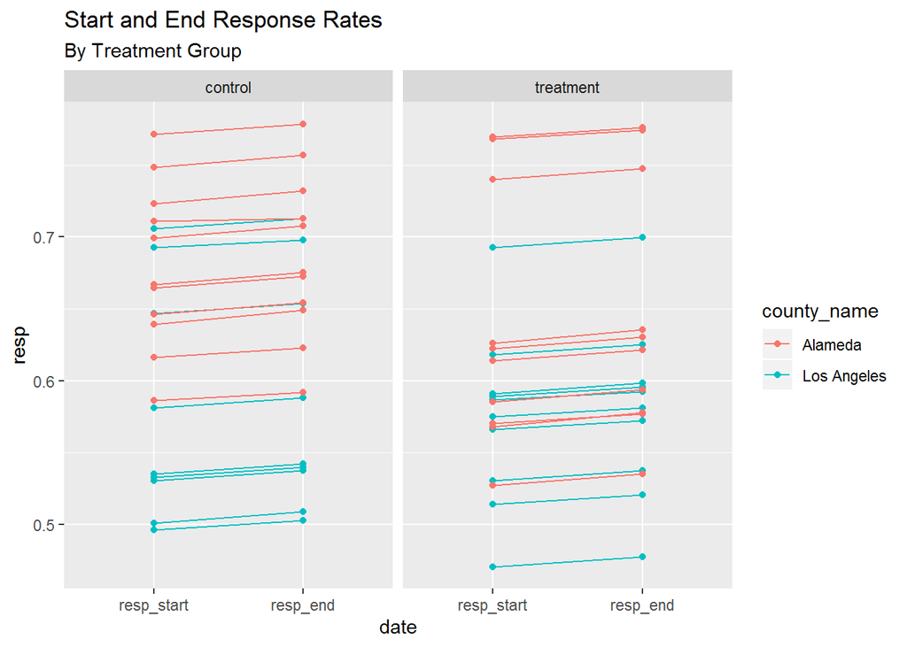

```r
datlong <-
dat %>%
  select(zip, county_name, exp_flag, resp_start, resp_end) %>%
  pivot_longer(-c(zip, county_name, exp_flag), names_to = "date", values_to = "resp") %>%
  mutate(date = factor(date, ordered=TRUE,
                       levels = c("resp_start", "resp_end")))



ggplot(datlong, aes(x=date, y=resp, group=zip, color=county_name)) +
  geom_line()+
  geom_point() +
  facet_wrap(~exp_flag) +
  labs(title="Start and End Response Rates",
       subtitle = "By Treatment Group")
```

### Distribution of Response Rate Gains

- The distribution of response rate gains for the control group is wider and ranges higher. More variability both low and high. Group means seem nearly equal, with the control group slightly higher.
- The distribution of response rate gains for the treatment group has a smaller range, with a top range that is a little lower than the control group.

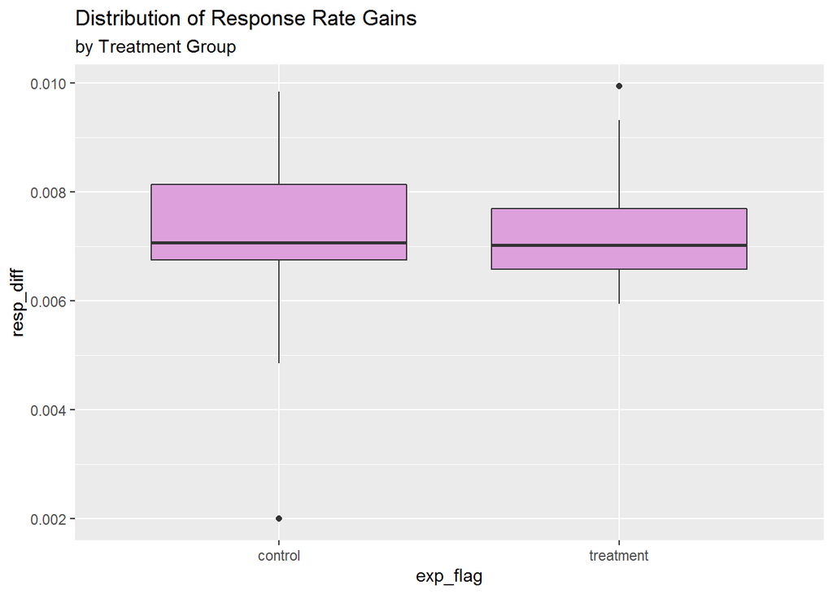

```r
dat %>%
  select(zip, county_name, exp_flag, resp_diff) %>%
  ggplot(aes(exp_flag, resp_diff)) +
  geom_boxplot(varwidth = T, fill="plum") +
  labs(title = "Distribution of Response Rate Gains",
       subtitle="by Treatment Group")
```

Distribution by group and county

- When the data is broken up by county, we see that there is way more variation in Alameda county than in Los Angeles.
- In both counties the control group has a slightly higher mean than the treatment group.
- In LA the treatment group varies more but the variation ranges lower than the control–top range of both are about the same.
- In Alameda county the bulk of the treatment group ranges slightly higher than the control group, and the bottom range is slightly higher as well.

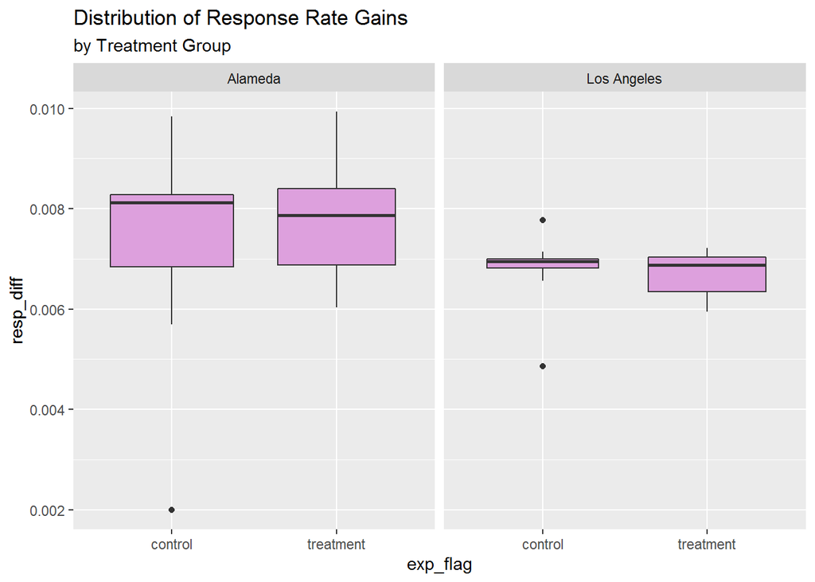

```r
  ggplot(dat, aes(exp_flag, resp_diff)) +
  geom_boxplot(varwidth = T, fill="plum") +
  facet_wrap(~county_name) +
  labs(title = "Distribution of Response Rate Gains",
       subtitle="by Treatment Group")
```

Detailed distribution (histogram)

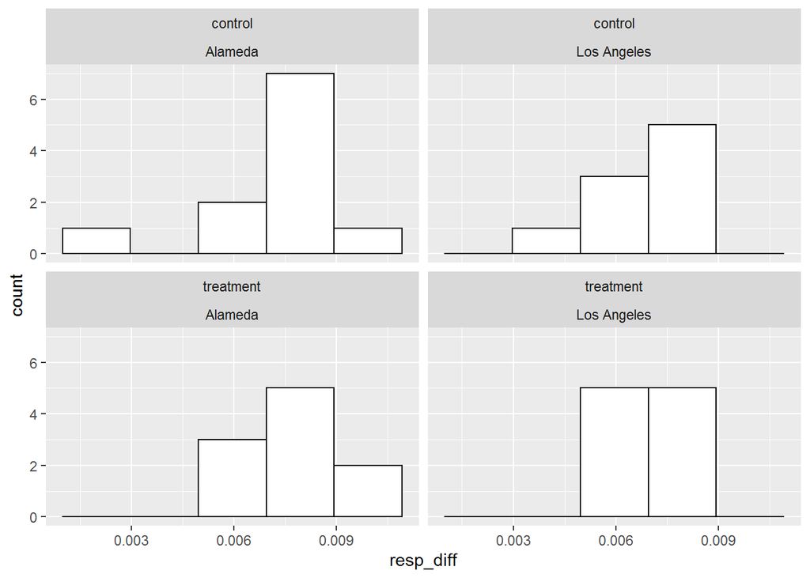

```r
ggplot(data = dat, aes(resp_diff)) +
  geom_histogram(bins = 5, fill="white", color="black") +
  facet_wrap(~exp_flag+county_name)
```

Review distribution of outreach metrics

- Overall the distribution of link clicks & impressions in LA zip codes skews higher than in Alameda

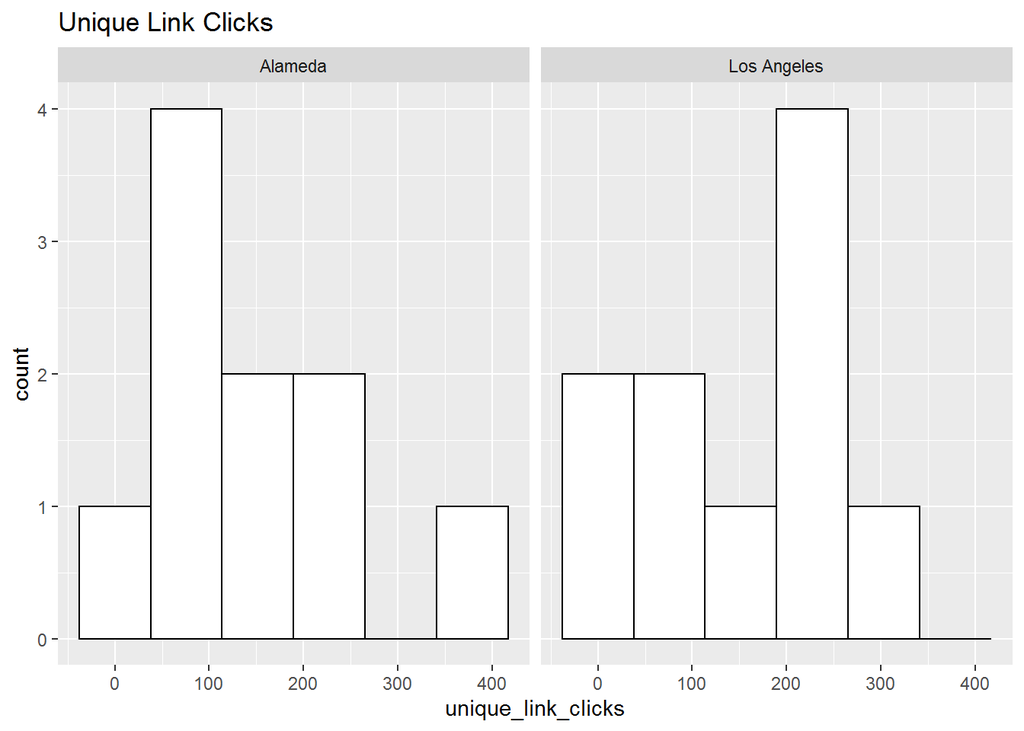

```r
ggplot(data=subset(dat, exp_flag=="treatment") , aes(unique_link_clicks)) +
  geom_histogram(bins=6, fill="white", color="black") +
  facet_wrap(~county_name) +
  labs(title="Unique Link Clicks")
```

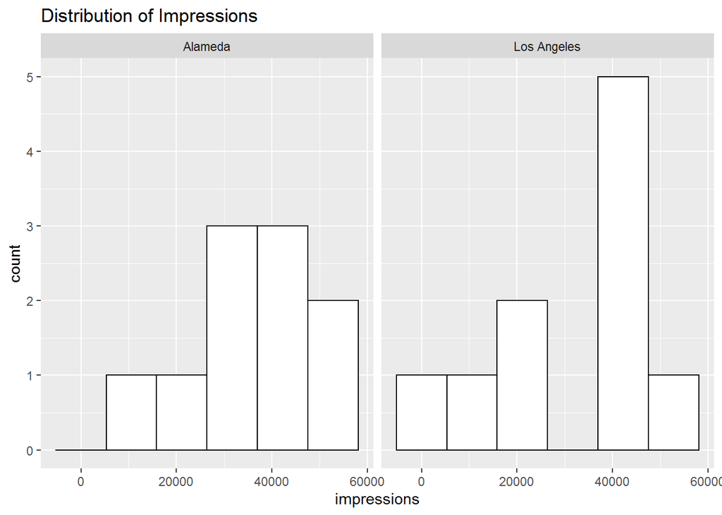

```r
ggplot(data=subset(dat, exp_flag=="treatment") , aes(impressions)) +
  geom_histogram(bins=6, fill="white", color="black") +
  facet_wrap(~county_name)+
  labs(title="Distribution of Impressions")
```

### Explore correlation of variables

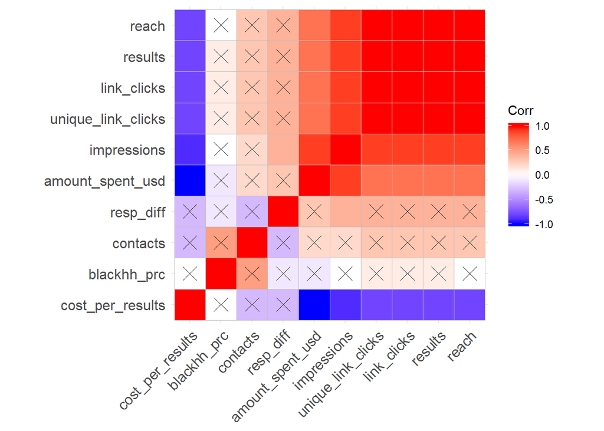

```r
library(ggcorrplot)

# prep data for correlation
# datcor_treatment <-
#   dat %>%
#   filter(exp_flag=="treatment") %>%
#   select(blackhh_prc, foreign.born, internet, multiunit, poverty, renter, mean_blkhtc_num, results, reach, impressions, link_clicks,
#          unique_link_clicks, amount_spent_usd, cost_per_results, contacts, resp_diff)


datcor_treatment <-
  dat %>%
  filter(exp_flag=="treatment") %>%
  select(blackhh_prc,resp_diff , results, reach, impressions, link_clicks,
         unique_link_clicks, amount_spent_usd, cost_per_results, contacts)


# create correlation matrix
treatment_corr <- round(cor(datcor_treatment), 1)
# save p values in case
p.mat <- cor_pmat(treatment_corr)

# test correlation
ggcorrplot(treatment_corr, hc.order = TRUE,
    p.mat = p.mat, sig.level = 0.05)
```

- In the correlation matric I see that the response rate gain has some positive correlation with key outreach metrics, but none of the correlations are statistically significant (at p < 0.5).
  - They are significant at p < 0.1, but, that’s not particularly significant.

### Review correlation of (non outreach) independent variables

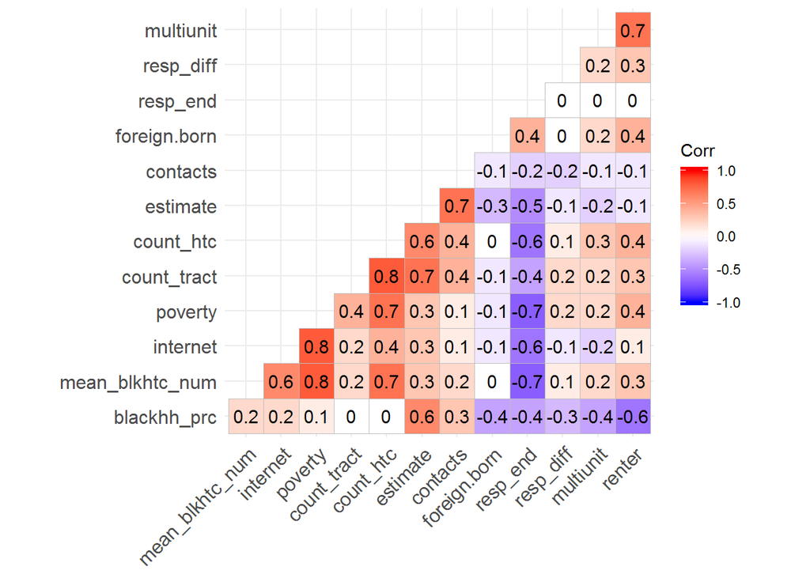

```r
datcor <-
  dat %>%
 # filter(exp_flag=="treatment") %>%
  select(estimate, blackhh_prc, foreign.born, internet, multiunit, poverty, renter, count_tract,
         count_htc, mean_blkhtc_num, contacts, resp_end, resp_diff)


# create correlation matrix
corr <- round(cor(datcor), 1)


# test correlation
ggcorrplot(corr, hc.order = TRUE, type = "lower",
   lab = TRUE)
```

- Poverty rate is strongly correlated with the mean Black HTC score and lack of internet, not surprisingly.
- I’ll check the collinearity of variables later.

### Plot linear regression

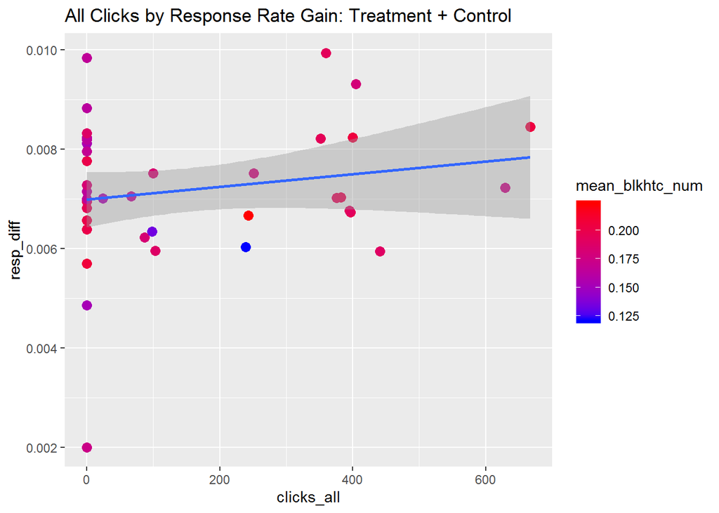

```r
ggplot(dat, aes(x=clicks_all, y=resp_diff)) +
  geom_point(aes(color=mean_blkhtc_num), size=3) +
  scale_color_gradient(low="blue", high="red")+
  geom_smooth(method = lm) +
  labs(title="All Clicks by Response Rate Gain: Treatment + Control")
```

- When I disaggregate by county we see pretty drastic differences between LA County and Alameda County. Alameda county shows a fairly strong linear relationship though a very large confidence interval (similar to boxplots above), while the LA County plot shows very slight positive relationship, though the line is mostly level.
- This tells me I should consider handling the counties separately, or a multilevel model.

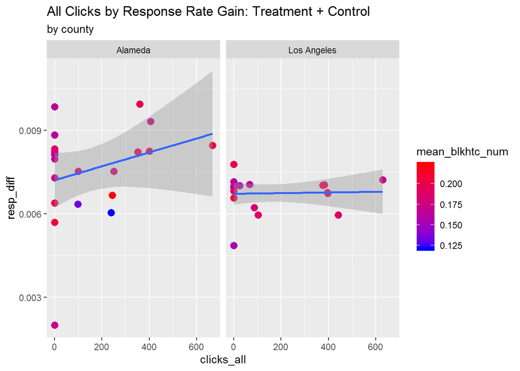

```r
ggplot(dat, aes(x=clicks_all, y=resp_diff)) +
    geom_point(aes(color=mean_blkhtc_num), size=3) +
  scale_color_gradient(low="blue", high="red")+
  geom_smooth(method = lm) +
    facet_wrap(~county_name) +
  labs(title="All Clicks by Response Rate Gain: Treatment + Control", subtitle="by county")
```

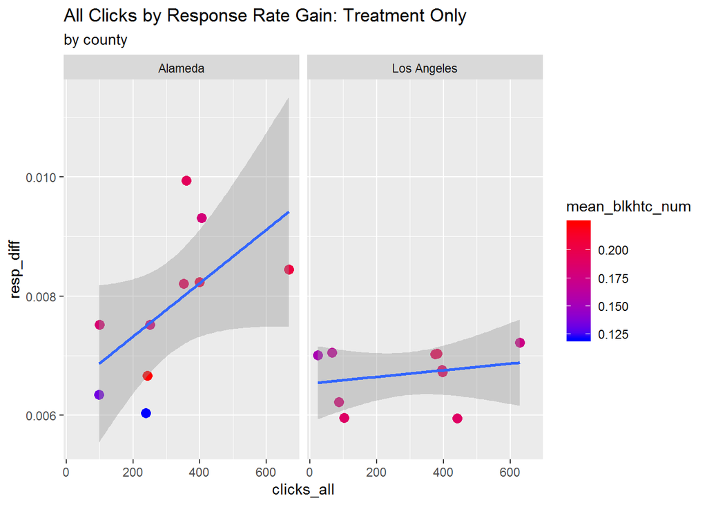

```r
ggplot(subset(dat, exp_flag=="treatment"), aes(x=clicks_all, y=resp_diff)) +
    geom_point(aes(color=mean_blkhtc_num), size=3) +
  scale_color_gradient(low="blue", high="red")+
  geom_smooth(method = lm) +
  facet_wrap(~county_name) +
  labs(title="All Clicks by Response Rate Gain: Treatment Only", subtitle = "by county")
```

## 3. Model Testing

- dependent variable: response rate gain
- independent variables: demographics, outreach, treatment group
- Separate counties (also try together)

```r
 #make a dummy variable for treatment
dat$treat_dummy <- ifelse(dat$exp_flag =="control", 0, 1)
table(dat$treat_dummy, dat$exp_flag, useNA = "always")  # verify
```

```
##
##        control treatment <NA>
##   0         20         0    0
##   1          0        20    0
##   <NA>       0         0    0
```

### A. All Counties

```r
# test full model - first with clicks
full_model_clicks <- lm(resp_diff ~ blackhh_prc + foreign.born + internet + multiunit +  poverty + #renter +  count_htc +
                   mean_blkhtc_num + resp_end  + clicks_all , data = dat) # contacts

# test full model - with reach
full_model_reach <- lm(resp_diff ~ blackhh_prc + foreign.born + internet + multiunit + poverty + #renter + count_htc +
                   mean_blkhtc_num + resp_end + contacts + reach , data = dat)

# review
summary(full_model_clicks)
```

```
##
## Call:
## lm(formula = resp_diff ~ blackhh_prc + foreign.born + internet +
##     multiunit + poverty + mean_blkhtc_num + resp_end + clicks_all,
##     data = dat)
##
## Residuals:
##         Min          1Q      Median          3Q         Max
## -0.00296812 -0.00048482 -0.00009546  0.00067187  0.00279898
##
## Coefficients:
##                     Estimate   Std. Error t value Pr(>|t|)
## (Intercept)      0.011301081  0.005942788   1.902   0.0665 .
## blackhh_prc     -0.001852712  0.001367283  -1.355   0.1852
## foreign.born    -0.000450757  0.002958958  -0.152   0.8799
## internet        -0.012234116  0.004539108  -2.695   0.0113 *
## multiunit       -0.001861382  0.002444013  -0.762   0.4520
## poverty          0.013534771  0.005555751   2.436   0.0208 *
## mean_blkhtc_num -0.013123820  0.020741398  -0.633   0.5315
## resp_end        -0.001138767  0.005109972  -0.223   0.8251
## clicks_all       0.000001228  0.000001094   1.122   0.2704
## ---
## Signif. codes:  0 '***' 0.001 '**' 0.01 '*' 0.05 '.' 0.1 ' ' 1
##
## Residual standard error: 0.001257 on 31 degrees of freedom
## Multiple R-squared:  0.3352, Adjusted R-squared:  0.1636
## F-statistic: 1.953 on 8 and 31 DF,  p-value: 0.08693
```

```r
summary(full_model_reach)
```

```
##
## Call:
## lm(formula = resp_diff ~ blackhh_prc + foreign.born + internet +
##     multiunit + poverty + mean_blkhtc_num + resp_end + contacts +
##     reach, data = dat)
##
## Residuals:
##         Min          1Q      Median          3Q         Max
## -0.00312543 -0.00053495  0.00001923  0.00059517  0.00274205
##
## Coefficients:
##                       Estimate     Std. Error t value Pr(>|t|)
## (Intercept)      0.01105579389  0.00605560670   1.826   0.0779 .
## blackhh_prc     -0.00156592805  0.00143086584  -1.094   0.2825
## foreign.born    -0.00038006042  0.00300392738  -0.127   0.9002
## internet        -0.01192221127  0.00461758846  -2.582   0.0150 *
## multiunit       -0.00186085238  0.00248374285  -0.749   0.4596
## poverty          0.01333859946  0.00567633126   2.350   0.0256 *
## mean_blkhtc_num -0.01221788429  0.02114152536  -0.578   0.5676
## resp_end        -0.00105833213  0.00519439930  -0.204   0.8399
## contacts        -0.00000104020  0.00000147876  -0.703   0.4872
## reach            0.00000008668  0.00000008317   1.042   0.3056
## ---
## Signif. codes:  0 '***' 0.001 '**' 0.01 '*' 0.05 '.' 0.1 ' ' 1
##
## Residual standard error: 0.001276 on 30 degrees of freedom
## Multiple R-squared:  0.3371, Adjusted R-squared:  0.1382
## F-statistic: 1.695 on 9 and 30 DF,  p-value: 0.134
```

```r
# review collinearity
vif(full_model_clicks)
```

```
##     blackhh_prc    foreign.born        internet       multiunit
##        1.790506        1.890750        3.699655        1.981126
##         poverty mean_blkhtc_num        resp_end      clicks_all
##        6.082914        4.638159        4.408778        1.159393
```

```r
vif(full_model_reach)
```

```
##     blackhh_prc    foreign.born        internet       multiunit
##        1.903246        1.891356        3.716111        1.985896
##         poverty mean_blkhtc_num        resp_end        contacts
##        6.163106        4.677138        4.421706        1.223000
##           reach
##        1.225285
```

```r
# remove some correlated variables like poverty/


# MASS::stepAIC(full_model_clicks)
# MASS::stepAIC(full_model_reach)

# test stepaic model
part_mod_clicks <- lm(resp_diff ~ internet + poverty + clicks_all, data = dat)
summary(part_mod_clicks)
```

```
##
## Call:
## lm(formula = resp_diff ~ internet + poverty + clicks_all, data = dat)
##
## Residuals:
##        Min         1Q     Median         3Q        Max
## -0.0032190 -0.0005505 -0.0001167  0.0008811  0.0028757
##
## Coefficients:
##                 Estimate   Std. Error t value             Pr(>|t|)
## (Intercept)  0.007355729  0.000539027  13.646 0.000000000000000848 ***
## internet    -0.011135719  0.003585484  -3.106              0.00369 **
## poverty      0.010467607  0.003491498   2.998              0.00490 **
## clicks_all   0.000001026  0.000001064   0.965              0.34115
## ---
## Signif. codes:  0 '***' 0.001 '**' 0.01 '*' 0.05 '.' 0.1 ' ' 1
##
## Residual standard error: 0.001234 on 36 degrees of freedom
## Multiple R-squared:  0.2557, Adjusted R-squared:  0.1937
## F-statistic: 4.123 on 3 and 36 DF,  p-value: 0.01301
```

```r
# part_mod_reach <- lm(resp_diff ~ internet + poverty + reach, data = dat)
#
# summary(part_mod_reach)
```

- The model resp_diff ~ internet + poverty + clicks_all ends up being the best fit so far, even though for *the best fit* (according to AIC), I would remove the outreach variable.

#### Test full model with all the different outreach metrics

```r
modoutreach <- lm(resp_diff ~ blackhh_prc + foreign.born + internet + multiunit +  poverty + renter + mean_blkhtc_num + contacts + resp_end +
               reach + frequency + cost_per_results + ad_set_budget + amount_spent_usd +impressions + cpm_cost_per_1_000_impressions_usd +
               link_clicks + clicks_all +ctr_all + unique_link_clicks +
                  clicks_all, data = dat)
summary(modoutreach)
```

```
##
## Call:
## lm(formula = resp_diff ~ blackhh_prc + foreign.born + internet +
##     multiunit + poverty + renter + mean_blkhtc_num + contacts +
##     resp_end + reach + frequency + cost_per_results + ad_set_budget +
##     amount_spent_usd + impressions + cpm_cost_per_1_000_impressions_usd +
##     link_clicks + clicks_all + ctr_all + unique_link_clicks +
##     clicks_all, data = dat)
##
## Residuals:
##         Min          1Q      Median          3Q         Max
## -0.00275497 -0.00048419 -0.00001724  0.00060979  0.00182443
##
## Coefficients:
##                                         Estimate    Std. Error t value
## (Intercept)                         0.0125864806  0.0072610083   1.733
## blackhh_prc                        -0.0018560225  0.0023736991  -0.782
## foreign.born                       -0.0012626585  0.0036256034  -0.348
## internet                           -0.0156503272  0.0059142356  -2.646
## multiunit                          -0.0038803754  0.0037043186  -1.048
## poverty                             0.0127592542  0.0077283048   1.651
## renter                              0.0022876445  0.0028904072   0.791
## mean_blkhtc_num                    -0.0178149470  0.0253816188  -0.702
## contacts                           -0.0000003899  0.0000020316  -0.192
## resp_end                           -0.0014471768  0.0063800256  -0.227
## reach                              -0.0000013934  0.0000016972  -0.821
## frequency                          -0.0002021915  0.0007246692  -0.279
## cost_per_results                    0.0003925358  0.0010727864   0.366
## ad_set_budget                      -0.0000243639  0.0000291524  -0.836
## amount_spent_usd                   -0.0000109502  0.0000336261  -0.326
## impressions                         0.0000002987  0.0000003084   0.969
## cpm_cost_per_1_000_impressions_usd  0.0002649373  0.0003619896   0.732
## link_clicks                        -0.0000131911  0.0000513584  -0.257
## clicks_all                         -0.0000147283  0.0000395305  -0.373
## ctr_all                            -0.0041772438  0.0200627555  -0.208
## unique_link_clicks                  0.0000676485  0.0000700351   0.966
##                                    Pr(>|t|)
## (Intercept)                          0.0992 .
## blackhh_prc                          0.4439
## foreign.born                         0.7315
```

[output cut: 9 more lines]

```
## cost_per_results                     0.7185
## ad_set_budget                        0.4137
## amount_spent_usd                     0.7483
## impressions                          0.3449
## cpm_cost_per_1_000_impressions_usd   0.4732
## link_clicks                          0.8001
## clicks_all                           0.7136
## ctr_all                              0.8373
## unique_link_clicks                   0.3462
## ---
## Signif. codes:  0 '***' 0.001 '**' 0.01 '*' 0.05 '.' 0.1 ' ' 1
##
## Residual standard error: 0.001343 on 19 degrees of freedom
## Multiple R-squared:  0.5353, Adjusted R-squared:  0.04612
## F-statistic: 1.094 on 20 and 19 DF,  p-value: 0.4237
```

```r
# reduce variables
#MASS::stepAIC(modoutreach)

# step aic suggests this model:
modoutreach_2 <- lm(formula = resp_diff ~ blackhh_prc + internet + poverty + reach +
    ad_set_budget + amount_spent_usd + impressions + cpm_cost_per_1_000_impressions_usd,  data = dat)

summary(modoutreach_2)
```

```
##
## Call:
## lm(formula = resp_diff ~ blackhh_prc + internet + poverty + reach +
##     ad_set_budget + amount_spent_usd + impressions + cpm_cost_per_1_000_impressions_usd,
##     data = dat)
##
## Residuals:
##        Min         1Q     Median         3Q        Max
## -0.0032812 -0.0005670  0.0000774  0.0003883  0.0022409
##
## Coefficients:
##                                         Estimate    Std. Error t value
## (Intercept)                         0.0084988705  0.0006740355  12.609
## blackhh_prc                        -0.0021733541  0.0010979939  -1.979
## internet                           -0.0117912425  0.0038165190  -3.090
## poverty                             0.0094356331  0.0034778496   2.713
## reach                              -0.0000006808  0.0000003192  -2.133
## ad_set_budget                      -0.0000183476  0.0000116394  -1.576
## amount_spent_usd                   -0.0000199413  0.0000083225  -2.396
## impressions                         0.0000003027  0.0000001132   2.673
## cpm_cost_per_1_000_impressions_usd  0.0002631778  0.0001496861   1.758
##                                              Pr(>|t|)
## (Intercept)                        0.0000000000000966 ***
## blackhh_prc                                   0.05671 .
## internet                                      0.00421 **
## poverty                                       0.01078 *
## reach                                         0.04095 *
## ad_set_budget                                 0.12510
## amount_spent_usd                              0.02279 *
## impressions                                   0.01188 *
## cpm_cost_per_1_000_impressions_usd            0.08858 .
## ---
## Signif. codes:  0 '***' 0.001 '**' 0.01 '*' 0.05 '.' 0.1 ' ' 1
##
## Residual standard error: 0.001164 on 31 degrees of freedom
## Multiple R-squared:  0.4302, Adjusted R-squared:  0.2832
## F-statistic: 2.926 on 8 and 31 DF,  p-value: 0.01483
```

```r
vif(modoutreach_2)
```

```
##                        blackhh_prc                           internet
##                           1.347347                           3.051938
##                            poverty                              reach
##                           2.781431                          21.694390
##                      ad_set_budget                   amount_spent_usd
##                          31.729867                         122.515017
##                        impressions cpm_cost_per_1_000_impressions_usd
##                         162.493541                          62.048909
```

- When multiple outreach variables are included we get some signifcant variables, but collinearity is out of control

Revise:

```r
modoutreach_2 <- lm(formula = resp_diff ~ internet + poverty + amount_spent_usd ,  data = dat)
# amount_spent_usd

summary(modoutreach_2)
```

```
##
## Call:
## lm(formula = resp_diff ~ internet + poverty + amount_spent_usd,
##     data = dat)
##
## Residuals:
##        Min         1Q     Median         3Q        Max
## -0.0031716 -0.0005601 -0.0000419  0.0008430  0.0029275
##
## Coefficients:
##                       Estimate    Std. Error t value           Pr(>|t|)
## (Intercept)       0.0072852525  0.0005510312  13.221 0.0000000000000022
## internet         -0.0111319963  0.0036138426  -3.080            0.00395
## poverty           0.0109830469  0.0034529404   3.181            0.00302
## amount_spent_usd  0.0000005293  0.0000008178   0.647            0.52165
##
## (Intercept)      ***
## internet         **
## poverty          **
## amount_spent_usd
## ---
## Signif. codes:  0 '***' 0.001 '**' 0.01 '*' 0.05 '.' 0.1 ' ' 1
##
## Residual standard error: 0.001243 on 36 degrees of freedom
## Multiple R-squared:  0.2453, Adjusted R-squared:  0.1824
## F-statistic: 3.899 on 3 and 36 DF,  p-value: 0.01644
```

```r
vif(modoutreach_2)
```

```
##         internet          poverty amount_spent_usd
##         2.398948         2.403624         1.037198
```

- I tested a bunch of different variable combinations here and no matter what we’re going to get massive collinearity if more than 1 outreach metric is included. When only 1 is included, the model is pretty similar regardless of the variable (which makes sense if they’re all collinear).

### B. Separate Counties

#### Los Angeles County

```r
# test full model - with clicks because they have seemed the best so far
### test los angeles county
la_mod <- lm(resp_diff ~ blackhh_prc + foreign.born + internet + multiunit +  poverty + renter + mean_blkhtc_num + contacts + resp_end +
               reach + frequency + cost_per_results + ad_set_budget + amount_spent_usd +impressions + cpm_cost_per_1_000_impressions_usd +
               link_clicks + clicks_all +ctr_all + unique_link_clicks +
                  clicks_all, data = dat[dat$county_name =="Los Angeles", ])
summary(la_mod)
```

```
##
## Call:
## lm(formula = resp_diff ~ blackhh_prc + foreign.born + internet +
##     multiunit + poverty + renter + mean_blkhtc_num + contacts +
##     resp_end + reach + frequency + cost_per_results + ad_set_budget +
##     amount_spent_usd + impressions + cpm_cost_per_1_000_impressions_usd +
##     link_clicks + clicks_all + ctr_all + unique_link_clicks +
##     clicks_all, data = dat[dat$county_name == "Los Angeles",
##     ])
##
## Residuals:
## ALL 19 residuals are 0: no residual degrees of freedom!
##
## Coefficients: (2 not defined because of singularities)
##                                         Estimate Std. Error t value
## (Intercept)                        -0.0427439161         NA      NA
## blackhh_prc                        -0.0073288057         NA      NA
## foreign.born                       -0.0083790269         NA      NA
## internet                            0.0001380195         NA      NA
## multiunit                           0.0035676836         NA      NA
## poverty                             0.0306372624         NA      NA
## renter                              0.0015627787         NA      NA
## mean_blkhtc_num                     0.0715849889         NA      NA
## contacts                            0.0000007207         NA      NA
## resp_end                            0.0547573001         NA      NA
## reach                               0.0000037733         NA      NA
## frequency                           0.0014116674         NA      NA
## cost_per_results                    0.0065132269         NA      NA
## ad_set_budget                      -0.0001485506         NA      NA
## amount_spent_usd                    0.0000944982         NA      NA
## impressions                        -0.0000015763         NA      NA
## cpm_cost_per_1_000_impressions_usd -0.0021540203         NA      NA
## link_clicks                         0.0000839099         NA      NA
## clicks_all                         -0.0000099142         NA      NA
## ctr_all                                       NA         NA      NA
## unique_link_clicks                            NA         NA      NA
##                                    Pr(>|t|)
## (Intercept)                              NA
## blackhh_prc                              NA
## foreign.born                             NA
## internet                                 NA
## multiunit                                NA
## poverty                                  NA
## renter                                   NA
## mean_blkhtc_num                          NA
## contacts                                 NA
## resp_end                                 NA
## reach                                    NA
## frequency                                NA
## cost_per_results                         NA
## ad_set_budget                            NA
## amount_spent_usd                         NA
## impressions                              NA
## cpm_cost_per_1_000_impressions_usd       NA
## link_clicks                              NA
## clicks_all                               NA
## ctr_all                                  NA
## unique_link_clicks                       NA
##
## Residual standard error: NaN on 0 degrees of freedom
## Multiple R-squared:      1,  Adjusted R-squared:    NaN
## F-statistic:   NaN on 18 and 0 DF,  p-value: NA
```

```r
# run stepAIC
#MASS::stepAIC(la_mod)
```

Test the reduced model:

```r
# reduced ind vars for la
la_mod_part <- lm(resp_diff ~ internet + clicks_all, data = dat[dat$county_name =="Los Angeles", ])
summary(la_mod_part) # IF I take out the clicks then the adj r squared is positive...but...
```

```
##
## Call:
## lm(formula = resp_diff ~ internet + clicks_all, data = dat[dat$county_name ==
##     "Los Angeles", ])
##
## Residuals:
##         Min          1Q      Median          3Q         Max
## -0.00174508 -0.00022237  0.00005001  0.00050718  0.00068862
##
## Coefficients:
##                   Estimate     Std. Error t value       Pr(>|t|)
## (Intercept)  0.00621001528  0.00042396309  14.648 0.000000000109 ***
## internet     0.00226989870  0.00171537060   1.323          0.204
## clicks_all  -0.00000007425  0.00000073315  -0.101          0.921
## ---
## Signif. codes:  0 '***' 0.001 '**' 0.01 '*' 0.05 '.' 0.1 ' ' 1
##
## Residual standard error: 0.0006313 on 16 degrees of freedom
## Multiple R-squared:  0.09999,    Adjusted R-squared:  -0.01251
## F-statistic: 0.8888 on 2 and 16 DF,  p-value: 0.4305
```

- Not a promising model…

#### Alameda County

```r
### test alameda county
alameda_mod <- lm(resp_diff ~ blackhh_prc + foreign.born + internet + multiunit +  poverty + #renter +  count_htc +
                   mean_blkhtc_num + resp_end  + clicks_all, data = dat[dat$county_name =="Alameda", ])
summary(alameda_mod)
```

```
##
## Call:
## lm(formula = resp_diff ~ blackhh_prc + foreign.born + internet +
##     multiunit + poverty + mean_blkhtc_num + resp_end + clicks_all,
##     data = dat[dat$county_name == "Alameda", ])
##
## Residuals:
##        Min         1Q     Median         3Q        Max
## -0.0032903 -0.0006197  0.0002646  0.0008790  0.0020957
##
## Coefficients:
##                     Estimate   Std. Error t value Pr(>|t|)
## (Intercept)      0.020364102  0.014333095   1.421    0.181
## blackhh_prc      0.001364282  0.005752712   0.237    0.817
## foreign.born     0.002970932  0.005125041   0.580    0.573
## internet        -0.016771843  0.008535327  -1.965    0.073 .
## multiunit       -0.003617452  0.004840218  -0.747    0.469
## poverty          0.016283831  0.009568063   1.702    0.115
## mean_blkhtc_num -0.039788386  0.039959033  -0.996    0.339
## resp_end        -0.007730555  0.013273816  -0.582    0.571
## clicks_all       0.000001322  0.000002638   0.501    0.625
## ---
## Signif. codes:  0 '***' 0.001 '**' 0.01 '*' 0.05 '.' 0.1 ' ' 1
##
## Residual standard error: 0.001741 on 12 degrees of freedom
## Multiple R-squared:  0.3898, Adjusted R-squared:  -0.01697
## F-statistic: 0.9583 on 8 and 12 DF,  p-value: 0.5082
```

```r
# reduced model but keep clicks in
alameda_mod_part <- lm(resp_diff ~ internet + poverty + clicks_all, data = dat[dat$county_name =="Alameda", ])
summary(alameda_mod_part)
```

```
##
## Call:
## lm(formula = resp_diff ~ internet + poverty + clicks_all, data = dat[dat$county_name ==
##     "Alameda", ])
##
## Residuals:
##        Min         1Q     Median         3Q        Max
## -0.0034250 -0.0011140  0.0003961  0.0009047  0.0024878
##
## Coefficients:
##                 Estimate   Std. Error t value    Pr(>|t|)
## (Intercept)  0.008231564  0.000939846   8.758 0.000000104 ***
## internet    -0.013640201  0.005752084  -2.371      0.0298 *
## poverty      0.008419625  0.004902805   1.717      0.1041
## clicks_all   0.000002639  0.000002056   1.284      0.2164
## ---
## Signif. codes:  0 '***' 0.001 '**' 0.01 '*' 0.05 '.' 0.1 ' ' 1
##
## Residual standard error: 0.001549 on 17 degrees of freedom
## Multiple R-squared:  0.3152, Adjusted R-squared:  0.1944
## F-statistic: 2.609 on 3 and 17 DF,  p-value: 0.08518
```

```r
# remove poverty variable
alameda_mod_part2 <- lm(resp_diff ~ internet + clicks_all, data = dat[dat$county_name =="Alameda", ])
summary(alameda_mod_part2)
```

```
##
## Call:
## lm(formula = resp_diff ~ internet + clicks_all, data = dat[dat$county_name ==
##     "Alameda", ])
##
## Residuals:
##        Min         1Q     Median         3Q        Max
## -0.0046926 -0.0007963  0.0003353  0.0012071  0.0020655
##
## Coefficients:
##                 Estimate   Std. Error t value     Pr(>|t|)
## (Intercept)  0.008586014  0.000965271   8.895 0.0000000524 ***
## internet    -0.008150362  0.005034215  -1.619       0.1228
## clicks_all   0.000003813  0.000002041   1.868       0.0781 .
## ---
## Signif. codes:  0 '***' 0.001 '**' 0.01 '*' 0.05 '.' 0.1 ' ' 1
##
## Residual standard error: 0.001631 on 18 degrees of freedom
## Multiple R-squared:  0.1964, Adjusted R-squared:  0.1072
## F-statistic:   2.2 on 2 and 18 DF,  p-value: 0.1397
```

- Looking at the reduced Alameda county model, if I remove the poverty var the adj R squared gets a lot lower but clicks becomes a bit significant.
- Basically the outreach variable doesn’t add anything in the model.
- As separate county models, neither model is very promising but LA County is worse (in that the model has no explanatory ability)

## 4. Answer Questions

### Primary question:

- *Did treatment zip codes have larger response rate gains than control zip codes?*
  - Overall, there is a slight trend of more clicks corresponding with higher response rate difference, but it is not a clear trend and the confidence intervals are large.
  - No statistically significant trends showing

### Secondary questions:

- *Are there any variables correlated with higher response rate gains?*
  - Looking at the correlation plot, none of the independent variables are correlated strongly with the response rate gain. The percent of Black households is slightly negatively correlated (-0.3) with response rate gain, but that is the strongest correlation.
  - Interestingly there is also no correlation (correlation = 0) between response rate and response rate gain–meaning that whether an area is high- or low-responding doesn’t necessarily correlate to whether the area was more likely to gain responses during this experiment.
- *Are there differences by county (Alameda vs. Los Angeles)?*
  - Yes, Alameda County shows huge variation by zip codes but also a generally stronger trend between response rate gains and outreach.
- *Are there additional contextual factors to consider? E.g. phone banking outreach from MBC*
  - The phone banking outreach doesn’t correlate with response rate gains. The independent variables lack of internet access and poverty rate are the 2 that are the best explanatory varibles, both better at explaining variation in zip code response rate gain than the outreach metrics.